# group_midus

## Dependencies

# Reproducibility group project, BST270 2024

## Introduction

In this Rmarkdown file we will attempt to reproduce the figures, tables and analyses presented in the paper *Relation between Optimism and Lipids in Midlife*.

1. Boehm, J. K., Williams, D. R., Rimm, E. B., Ryff, C., & Kubzansky, L. D. (2013). Relation between Optimism and Lipids in Midlife. The American Journal of Cardiology, 111(10), 1425-1431. http://doi.org/10.1016/j.amjcard.2013.01.292

In 1995, MIDUS survey data were collected from a total of 7,108 participants. The baseline sample was comprised of individuals from four subsamples: (1) a national RDD (random digit dialing) sample ($n = 3,487$); (2) oversamples from five metropolitan areas in the U.S. ($n = 757$); (3) siblings of individuals from the RDD sample ($n = 950$); and (4) a national RDD sample of twin pairs ($n = 1,914$). All eligible participants were non-institutionalized, English-speaking adults in the contiguous United States, aged 25 to 74. All respondents were invited to participate in a phone interview of approximately 30 minutes in length and complete 2 self-administered questionnaires (SAQs), each of approximately 45 pages in length. In addition, the twin subsample was administered a short screener to assess zygosity and other twin-specific information. With funding provided by the National Institute on Aging, a longitudinal follow-up of MIDUS I began in 2004. Every attempt was made to contact all original respondents and invite them to participate in a second wave of data collection. Of the 7,108 participants in MIDUS I, 4,963 were successfully contacted to participate in another phone interview of about 30 minutes in length. MIDUS II also included two self-administered questionnaires (SAQs), each of about 55 pages in length, which were mailed to participants. The overall response rate for the SAQs was 81%. Over 1,000 journal articles have been written using MIDUS I and II data since 1995.

Here we attempt to reproduce the findings of [1] and critique the reproducibility of the article. This particular article focuses only on MIDUS II data, including biomarker data, and investigates the relationship between optimism and lipids. The MIDUS II data and supporting codebook and other documents can be downloaded . The data can be downloaded in multiple formats. The biomarker data can be downloaded .

## Data Dictionary

This manuscript uses several variables from multiple data files. Some of these variables don’t have intuitive names and need to be manually looked up either online or in the codebooks provided in the data downloads. We generated a data dictionary to our understanding of the naming conventions.

Load packages

```r
library(dplyr)
library(tidyverse)
library(ggplot2)
library(DT)
#install.packages("gtsummary")

library(gtsummary)
```

We are trying to keep all functions well documented. This command allows us to have package-like documentation for all of the functions.

```r
if (!require('devtools')) install.packages('devtools')
```

## Read data

First we load the data. 29282-0001-Data contains the analysis-associated data, while 04652-0001-Data contains the midus clinical data.

```r
load('data/29282-0001-Data.rda')
load('data/04652-0001-Data.rda')
```

We have to merge the two tables based on the MIDUS II ID number

```r
data = inner_join(da04652.0001, da29282.0001, by = c("M2ID", "M2FAMNUM"),suffix = c('','.2'))
print(dim(data))
```

```
## [1] 1054 5415
```

Data has 1054 rows at the beginning after merging the two tables. Now we are going to try and reproduce the preprocessing steps such that we can obtain the 990 individuals they used for the paper analysis.

## Wrangle data

### Step 0. Filter optimism variables

Optimism is assessed using the 6-item Life-Orientation test. In the codebook we have found that B1SORIEN is the column with the results of the life orientation test. We excluded entries with -1 or non-integer values. We arbitrarily made this choice because we couln’t find any indication in the docs.

Here we are filtering the rows to remove the individuals who do not have an optimism score.

```r
# filter optimism variables
source("filter_optimism.R")
data_after_optimism_filtering <- Filter_optimism(data)
print(dim(data_after_optimism_filtering))
```

```
## [1] 1046    2
```

We are left with 1046 samples that optimism data.

Secondly, we clean the columns relative to lipids (Total cholesterol, HDL, LDL, triglicerydes).

### Step 1 Filter lipid measurements

```r
# filter and clean lipid measurement columns
source("filter_lipids.R")
data_after_lipid_filtering <- Filter_lipids(data)
print(dim(data_after_lipid_filtering))
```

```
## [1] 1043    5
```

After filtering lipid measurements, we have 1043 rows left

```r
temp_data <- inner_join(data_after_optimism_filtering,
                        data_after_lipid_filtering, by = "M2ID")

print(dim(temp_data))
```

```
## [1] 1035    6
```

1035 after filtering for both lipids and optimism

### Step 2 Filter pathway variables

```r
# filter pathway varibales
source("filter_pathway.R")
data_after_pathway_filtering <- filter_pathway(data)
print(dim(data_after_pathway_filtering))
```

```
## [1] 1048    6
```

We are left with 1048 samples

```r
temp_data <- inner_join(data_after_optimism_filtering,
                        data_after_lipid_filtering, by = "M2ID") %>%
              inner_join(data_after_pathway_filtering, by = "M2ID")

print(dim(temp_data))
```

```
## [1] 1031   11
```

1031 after pathway filtering.

The drinking variable was the hardest one to deal with, because there are multiple columns dedicated to it, and also the numbers in there are hard to understand.

### Step 3 Filter potential confounders

Finally we filter the potential confounders, such as age, sex, income..

```r
# filter confounders
source("filter_confounders.R")
data_after_confounder_filtering = Filter_confounders(data)
print(dim(data_after_confounder_filtering))
```

```
## [1] 1018   10
```

```r
temp_data <- inner_join(data_after_optimism_filtering,
                        data_after_lipid_filtering, by = "M2ID") %>%
              inner_join(data_after_pathway_filtering, by = "M2ID") %>%
  inner_join(data_after_confounder_filtering, by = "M2ID")

print(dim(temp_data))
```

```
## [1] 996  20
```

Here we are left with 996 individuals

Let’s keep only the columns of interest

```r
full_data <- inner_join(data_after_optimism_filtering,
                        data_after_lipid_filtering, by = "M2ID") %>%
    inner_join(data_after_confounder_filtering, by = "M2ID") %>%
    inner_join(data_after_pathway_filtering, by = 'M2ID')

print(dim(full_data))
```

```
## [1] 996  20
```

```r
# all_columns = c(optimism_columns, lipid_columns, pathway_columns, confounder_columns)
#View(data_after_fc[,all_columns])
```

The data seems to be complete, but the documentation or methods section does not give full details on which columns they are using and how they filter them.

## Figure 1

First, we attempt to reproduce Figure 1. Figure 1 shows the frequency distribution of 990 optimism scores (mean +- SD: 23.95 +- 4.69), with black representing the lowest tertile of optimism (6 to 22), gray, middle tertile of optimism (23 to 26), and white, highest tertile of optimism (27 to 30)

```r
mean(full_data$B1SORIEN)
```

```
## [1] 23.97892
```

```r
sd(full_data$B1SORIEN)
```

```
## [1] 4.68533
```

```
##
##  Low  Med High
##  334  303  359
```

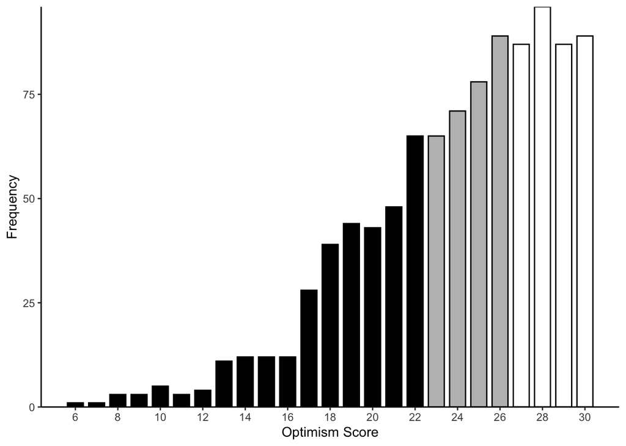

```r
#generate figure 1
source("figure1.R")
figure1(full_data) #print histogram
```

## Table 1

We then proceed to reproduce table 1. We are gonna split it in different chunks, based on the lipid/confounder/pathway groups.

### Confounder

```r
truncate_decimal <- function(x, digits) {
  factor <- 10^digits
  ifelse(x >= 0, floor(x * factor) / factor, ceiling(x * factor) / factor)
}

# generate table 1


source("pathway_tableone.R")
pathway_tableone(full_data)
```

```
## $tbsmoke
##                     optimism
##                      low moderate high
##   (1) current smoker  60       27   26
##   (2) past smoker    100      110  114
##   (3) never smoker   174      166  219
##
## $smokerow
##                       optimism
##                          low moderate  high
##   Current smoker row % 53.09    23.89 23.00
##   Past smoker row %    30.86    33.95 35.18
##   Never smoker row %   31.12    29.69 39.17
##
## $smokecol
##                       optimism
##                          low moderate  high
##   Current smoker col % 17.96     8.91  7.24
##   Past smoker col %    29.94    36.30 31.75
##   Never smoker col %   52.09    54.78 61.00
##
## $drinksPrudent
##
##
## |                               |high        |low         |medium      |p      |test |
## |:------------------------------|:-----------|:-----------|:-----------|:------|:----|
## |n                              |359         |334         |303         |       |     |
## |drinks_per_day (mean (SD))     |0.43 (0.74) |0.49 (0.91) |0.37 (0.63) |0.134  |     |
## |smoking_status (%)             |            |            |            |<0.001 |     |
## |(1) current smoker             |26 ( 7.2)   |60 (18.0)   |27 ( 8.9)   |       |     |
## |(2) past smoker                |114 (31.8)  |100 (29.9)  |110 (36.3)  |       |     |
## |(3) never smoker               |219 (61.0)  |174 (52.1)  |166 (54.8)  |       |     |
## |prudent_diet_score (mean (SD)) |4.46 (1.37) |3.85 (1.44) |4.22 (1.33) |<0.001 |     |
##
## $smokeRow
##
##
## |             |(1) current smoker |(2) past smoker |(3) never smoker |p      |test |
## |:------------|:------------------|:---------------|:----------------|:------|:----|
## |n            |113                |324             |559              |       |     |
## |optimism (%) |                   |                |                 |<0.001 |     |
## |high         |26 (23.0)          |114 (35.2)      |219 (39.2)       |       |     |
## |low          |60 (53.1)          |100 (30.9)      |174 (31.1)       |       |     |
## |medium       |27 (23.9)          |110 (34.0)      |166 (29.7)       |       |     |
```

```r
exercise_tbl(full_data)
```

```
##         Metric      Low   Medium     High
## 1 Yes Column % 73.95210 83.82838 80.50139
## 2    Yes Row % 31.26582 32.15190 36.58228
## 3  No Column % 26.04790 16.17162 19.49861
## 4     No Row % 42.23301 23.78641 36.58228
```

```r
source("generate_table1_confounding.R")
generate_confounding_table1(full_data)
```

```
## [1] "Education Level"
##                    low  moderate      high
## 1 (Column %)  5.947955  2.717391  2.506964
## 1 (Row %)    45.714286 28.571429 25.714286
## 2 (Column %) 26.765799 21.467391 15.320334
## 2 (Row %)    34.951456 38.349515 26.699029
## 3 (Column %) 21.933086 23.641304 18.941504
## 3 (Row %)    27.570093 40.654206 31.775701
## 4 (Column %) 45.353160 52.173913 63.231198
## 4 (Row %)    22.550832 35.489834 41.959335
##
##  Pearson's Chi-squared test
##
## data:  table(full_data$education_categorical, full_data$optimism_category)
## X-squared = 27.594, df = 6, p-value = 0.000112
##
## [1] "Race"
##                           low  moderate      high
## Nonwhite (Column %)  8.550186  5.706522  6.685237
## Nonwhite (Row %)    33.823529 30.882353 35.294118
## White (Column %)    91.449814 94.293478 93.314763
## White (Row %)       26.508621 37.392241 36.099138
##
##  Pearson's Chi-squared test
##
## data:  table(full_data$race, full_data$optimism_category)
## X-squared = 1.9933, df = 2, p-value = 0.3691
##
## [1] "Gender"
##                            low moderate     high
## (1) Male (Column %)   47.95539 45.92391 42.61838
## (1) Male (Row %)      28.60310 37.47228 33.92461
## (2) Female (Column %) 52.04461 54.07609 57.38162
## (2) Female (Row %)    25.68807 36.51376 37.79817
##
##  Pearson's Chi-squared test
##
## data:  table(full_data$sex, full_data$optimism_category)
## X-squared = 1.8651, df = 2, p-value = 0.3935
##
```

[output cut: 19 more lines]

```
##
##  Pearson's Chi-squared test
##
## data:  table(full_data$blood_pressure_med, full_data$optimism_category)
## X-squared = 4.4559, df = 2, p-value = 0.1077
##
## [1] "Negative Affect"
##                   [,1]          [,2]          [,3]
## optimism_category "low"         "moderate"    "high"
## mean_sd           "1.81 ± 0.63" "1.49 ± 0.43" "1.35 ± 0.34"
##
##  Pearson's Chi-squared test
##
## data:  bp_table
## X-squared = 4.4559, df = 2, p-value = 0.1077
```

```r
# generate table 1 based on the lipid variables
source("table_1_lipid.R")
table_1_lipid(full_data)
```

[output not shown]

| **Characteristic** | **Optimism** **Low** N = 334<sup>1</sup> | **Optimism** **Moderate** N = 303<sup>1</sup> | **Optimism** **High** N = 359<sup>1</sup> | **p-value** |  |
| --- | --- | --- | --- | --- | --- |
| Total cholesterol | 188.59 ± 38.60 | 184.78 ± 38.58 | 187.07 ± 39.23 |  |  |
| High-density lipoprotein cholesterol | 52.83 ± 17.49 | 53.93 ± 16.66 | 57.10 ± 18.20 |  |  |
| Low-density lipoprotein cholesterol | 109.24 ± 34.86 | 104.84 ± 34.98 | 105.49 ± 34.90 |  |  |
| Triglycerides | 134.75 ± 83.85 | 131.88 ± 83.72 | 122.88 ± 68.27 |  |  |

<sup>1</sup> Mean ± SD

## Table 2

```r
fig2_cols <- c("Optimism", "Age", "Gender", "Race", "Education", "Income",
               "Interval between assessments", "Chronic conditions",
               "Blood pressure medication", "Body mass index", "Smoking status",
               "Alcohol consumption", "Prudent diet", "Regular exercise",
               "Negative affect")
cor_data <- full_data %>%
    mutate(Optimism = B1SORIEN,
           Age = as.numeric(age),
           Gender = case_when(sex == '(1) Male' ~ 0,
                              sex == '(2) Female' ~ 1),
           Race = case_when(race == 'White' ~ 0,
                            race == 'Nonwhite' ~ 1),
           Education = education_categorical,
           Income = household_income,
           `Interval between assessments` = visit_interval,
           `Chronic conditions` = case_when(chronic_condition == '(0) No' ~ 0,
                                            chronic_condition == '(1) Yes' ~ 1),
           `Blood pressure medication` = case_when(blood_pressure_med == '(2) No' | blood_pressure_med == '2' ~ 0,
                                                   blood_pressure_med == '1' ~ 1),
           `Body mass index` = BMI,
           `Smoking status` = case_when(smoking_status == '(1) current smoker' ~ 1,
                                        smoking_status == '(2) past smoker' ~ 2,
                                        smoking_status == '(3) never smoker' ~ 3),
           `Alcohol consumption` = drinks_per_day,
           `Prudent diet` = prudent_diet_score,
           `Regular exercise` = case_when(regular_exercise == '(2) No' ~ 0,
                                          regular_exercise == '(1) Yes' ~ 1),
           `Negative affect` = negative_affect) %>%
    select(all_of(fig2_cols))

results_df <- data.frame(matrix(ncol = 3, nrow = length(fig2_cols) - 1))
colnames(results_df) <- c("Characteristic", "r", "p")
for (i in seq(fig2_cols[-1])) {
    colname <- fig2_cols[-1][i]
    cor_val <- c(cor(cor_data[colname], cor_data$Optimism, method = 'pearson'))
    lm_model <- lm(cor_data$Optimism ~ unlist(cor_data[colname]))
    pval <- coef(summary(lm_model))[2, 'Pr(>|t|)']
    results_df$Characteristic[i] <- colname
    results_df$r[i] <- cor_val
    results_df$p[i] <- pval
}

results_df <- results_df %>%
    mutate(r = round(r, 2),
           p = case_when(p < 0.0001 ~ "<0.0001",
                            p < 0.001 ~ "<0.001",
                            TRUE ~ as.character(round(p, 2))))

knitr::kable(results_df)
```

| Characteristic | r | p |
| --- | --- | --- |
| Age | 0.18 | <0.0001 |
| Gender | 0.02 | 0.48 |
| Race | -0.04 | 0.16 |
| Education | 0.16 | <0.0001 |
| Income | 0.14 | <0.0001 |
| Interval between assessments | 0.01 | 0.83 |
| Chronic conditions | -0.12 | <0.0001 |
| Blood pressure medication | 0.05 | 0.14 |
| Body mass index | -0.07 | 0.03 |
| Smoking status | 0.14 | <0.0001 |
| Alcohol consumption | -0.03 | 0.29 |
| Prudent diet | 0.20 | <0.0001 |
| Regular exercise | 0.06 | 0.04 |
| Negative affect | -0.45 | <0.0001 |

## Table 5

```r
#Filter data for table 5
source("lipid_risk.R")
Filter_lipids_bad(data)
```

```
## # A tibble: 1,045 × 15
##     M2ID B4BCHOL B4BTRIGL B4BHDL B4BLDL B4H1HD  B4XTCS_19 B1PRSEX    bad_chol
##    <dbl>   <dbl>    <dbl>  <dbl>  <dbl> <fct>   <fct>     <fct>      <lgl>
##  1 10002     106       92     38     50 <NA>    (2) No    (1) Male   FALSE
##  2 10005     223      187     39    147 <NA>    (2) No    (2) Female FALSE
##  3 10019     123       98     25     78 (2) No  (2) No    (1) Male   FALSE
##  4 10040     174       56     54    109 <NA>    (2) No    (1) Male   FALSE
##  5 10047     164       90     82     64 <NA>    (2) No    (2) Female FALSE
##  6 10060     256      225     45    166 (1) Yes (2) No    (1) Male   TRUE
##  7 10061     128       52     49     69 (2) No  (1) Yes   (1) Male   FALSE
##  8 10063     203       69     73    116 <NA>    (2) No    (2) Female FALSE
##  9 10087     125       28     53     66 <NA>    <NA>      (2) Female FALSE
## 10 10098     210       74     75    120 <NA>    (2) No    (2) Female FALSE
## # ℹ 1,035 more rows
## # ℹ 6 more variables: bad_hdl <lgl>, bad_ldl <lgl>, bad_tri <lgl>,
## #   bad_lipid_drug <lgl>, bad_lipid_disease <lgl>, bad_lipid_condition <lgl>
```